# ch7_PythonExample

## 7.4b The `Digits` Recognition Example

### Discriminant analysis in Python

To make the ideas concrete we use the handwritten ZIP-code digits from *The Elements of Statistical Learning*. In R the data originally in `ElemStatLearn` are now available in `tensorBSS`. Here we load the same flat files: each row is a label in $\{0,1,\ldots,9\}$ followed by a $16\times 16$ grayscale image stored as 256 pixels. The task is to classify the digit. We will try LDA, QDA, FDA, and naive Bayes.

ESL also provides a proper test set `zip.test` ($n = 2007$). Below we instead draw a small training/test split from `zip.train` so that the demonstration stays fast; you should feel free to repeat the analysis on the official `zip.test`.

```python
import numpy as np
import pandas as pd
import matplotlib.pyplot as plt
from pathlib import Path

from sklearn.discriminant_analysis import (
    LinearDiscriminantAnalysis,
    QuadraticDiscriminantAnalysis,
)
from sklearn.naive_bayes import GaussianNB
from sklearn.metrics import accuracy_score

from pathlib import Path
from urllib.request import urlretrieve
import gzip
import shutil
import pandas as pd

ESL_URL = "https://web.stanford.edu/~hastie/ElemStatLearn/datasets/zip.train.gz"
ZIP_TRAIN_PATH = Path.cwd() / "Downloads" / "zip.train"

def ensure_zip_train(path=ZIP_TRAIN_PATH):
    path = Path(path)
    path.parent.mkdir(parents=True, exist_ok=True)
    if path.exists() and path.stat().st_size > 0:
        print("Using cached file:", path.resolve())
        return path

    gz_path = path.with_name("zip.train.gz")
    print("Downloading", ESL_URL)
    print("Working directory:", Path.cwd())
    urlretrieve(ESL_URL, gz_path)
    with gzip.open(gz_path, "rb") as src, path.open("wb") as dst:
        shutil.copyfileobj(src, dst)
    print("Saved", path.resolve(), "size", path.stat().st_size)
    return path

def load_zip_dataset(path):
    return pd.read_csv(path, sep=r"\s+", header=None, engine="python", comment="#")

ZIP_TRAIN_PATH = ensure_zip_train()
zip_train_df = load_zip_dataset(ZIP_TRAIN_PATH)
print(zip_train_df.shape)  # expect (7291, 257)
```

```
Using cached file: /Users/alexandrachronopoulou/Library/CloudStorage/Dropbox/Teaching/CS 598 PSL/STAT 542 Online Book/Book Code for Examples/Downloads/zip.train
(7291, 257)
```

Column 1 (index 0 in Python) is the digit label; columns 2 through 257 are the pixels. A few training images:

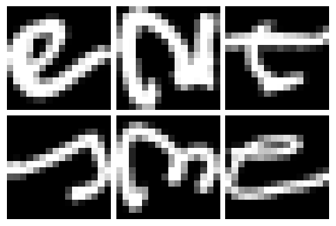

```python
fig, axes = plt.subplots(2, 3, figsize=(6, 4))
plt.subplots_adjust(wspace=0.05, hspace=0.05)

for i, ax in enumerate(axes.flat):
    v = zip_train_df.iloc[i, 1:].to_numpy(dtype=float)
    # R: matrix(..., nrow = 16, byrow = TRUE); then t(M)[, 16:1]
    M = v.reshape(16, 16, order="C").T[:, ::-1]
    ax.imshow(M, cmap="gray", interpolation="nearest", origin="lower")
    ax.axis("off")

plt.show()
```

A small split from `zip.train`. The RNG will not reproduce R's `sample()` exactly.

```python
rng = np.random.default_rng(598)
n = len(zip_train_df)
all_idx = np.arange(n)

train_idx = rng.choice(n, size=800, replace=False)
remaining_idx = np.setdiff1d(all_idx, train_idx, assume_unique=False)
test_idx = rng.choice(remaining_idx, size=200, replace=False)

train_zip = zip_train_df.iloc[train_idx].reset_index(drop=True)
test_zip  = zip_train_df.iloc[test_idx].reset_index(drop=True)

X_train = train_zip.iloc[:, 1:257].to_numpy(dtype=float)
Y_train = train_zip.iloc[:, 0].to_numpy(dtype=int)
X_test  = test_zip.iloc[:, 1:257].to_numpy(dtype=float)
Y_test  = test_zip.iloc[:, 0].to_numpy(dtype=int)

print(X_train.shape, Y_train.shape, X_test.shape, Y_test.shape)
```

```
(800, 256) (800,) (200, 256) (200,)
```

### Linear Discriminant Analysis (LDA)

sklearn's `LinearDiscriminantAnalysis` is the counterpart of R's `MASS::lda`. By default it uses the SVD solver, which is more stable than an explicit pooled-covariance inverse when $p$ is large.

```python
digits_lda = LinearDiscriminantAnalysis()
digits_lda.fit(X_train, Y_train)
```

```
LinearDiscriminantAnalysis()
```

Predict and compute the test accuracy. Uncomment the cross-tab if you want the full confusion matrix.

```python
Y_predicted = digits_lda.predict(X_test)
acc_lda = accuracy_score(Y_test, Y_predicted)
print(f"LDA test accuracy: {acc_lda:.3f}")

# pd.crosstab(pd.Series(Y_test, name="True"),
#             pd.Series(Y_predicted, name="Predicted"))
```

```
LDA test accuracy: 0.845
```

On a given 800/200 split the accuracy is typically in the mid-80s. The number will move if you change the seed or the split sizes; the official `zip.test` is a harder benchmark.

### Quadratic Discriminant Analysis (QDA)

With $p = 256$ pixels and only a few hundred observations per digit, each class covariance is rank-deficient. `MASS::qda` stops with an error. sklearn's `QuadraticDiscriminantAnalysis` will often *fit* anyway and emit a collinearity warning; the resulting rule is numerically unstable. A small `reg_param` is the analogue of the $\hat\Sigma_k + \eta I$ ridge used in the notes.

```python
# Unregularized QDA — ill-posed here (singular Sigma_k).
# digits_qda = QuadraticDiscriminantAnalysis()
# digits_qda.fit(X_train, Y_train)

# Optional regularized version, if you want a number to compare:
# digits_qda = QuadraticDiscriminantAnalysis(reg_param=0.05)
# digits_qda.fit(X_train, Y_train)
# print(accuracy_score(Y_test, digits_qda.predict(X_test)))
```

### Fisher Discriminant Analysis (FDA)

Project the data onto the Fisher directions. In R these are `lda()$scaling`; in sklearn they are `scalings_`. For ten digits there are at most $K-1 = 9$ directions.

`transform()` applies the same map after centering, which is the preferred way to get LD / FDA coordinates. Multiplying by `scalings_` alone skips the centering step and will not match `transform()`.

```python
FDA_digits_directions = digits_lda.scalings_
print(FDA_digits_directions.shape)  # (256, 9) if all 10 digits appear in the train split
```

```
(256, 9)
```

These directions turned out to be 9 in our case (provided every digit appears at least once in the training sample).

For illustration we display the projection onto the first two directions. Other pairs of columns tell different stories.

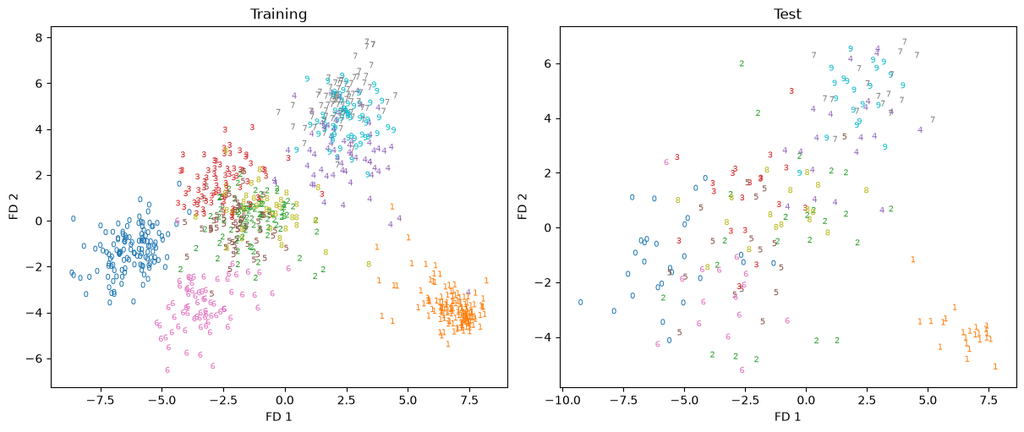

```python
F_train = digits_lda.transform(X_train)
F_test  = digits_lda.transform(X_test)

cmap = plt.cm.tab10

def plot_ld_text(ax, F, y, title):
    ax.set_title(title)
    ax.set_xlabel("FD 1")
    ax.set_ylabel("FD 2")
    for xi, yi, lab in zip(F[:, 0], F[:, 1], y):
        ax.text(xi, yi, str(int(lab)), color=cmap(int(lab) % 10),
                fontsize=7, ha="center", va="center")
    x1, x2 = np.min(F[:, 0]), np.max(F[:, 0])
    y1, y2 = np.min(F[:, 1]), np.max(F[:, 1])
    mx, my = 0.05 * (x2 - x1 + 1e-8), 0.05 * (y2 - y1 + 1e-8)
    ax.set_xlim(x1 - mx, x2 + mx)
    ax.set_ylim(y1 - my, y2 + my)

fig, axes = plt.subplots(1, 2, figsize=(12, 5), constrained_layout=True)
plot_ld_text(axes[0], F_train, Y_train, "Training")
plot_ld_text(axes[1], F_test,  Y_test,  "Test")
plt.show()
```

#### Computational remarks

We can recover the same directions by forming $W$ and $B$ explicitly. In R this was a no-intercept dummy regression of the features on the class labels. The Python equivalent is: residuals $\mathbf{x}_i - \hat\mu_{y_i}$ and fitted values $\hat\mu_{y_i}$.

```python
X = np.asarray(X_train, dtype=float)
y = np.asarray(Y_train)
n, p = X.shape
classes = np.unique(y)

mu = np.vstack([X[y == c].mean(axis=0) for c in classes])
class_index = {c: i for i, c in enumerate(classes)}
mu_y = np.vstack([mu[class_index[ci]] for ci in y])  # fitted class means
R = X - mu_y                                         # residuals

W = np.cov(R, rowvar=False, bias=False)              # within-class / pooled
B = np.cov(mu_y, rowvar=False, bias=False)           # between-class (R: cov(fitted))

eigvals_W, eigvecs_W = np.linalg.eigh(W)
print("W eigenvalues: min / median / max =",
      eigvals_W.min(), np.median(eigvals_W), eigvals_W.max())
print("Number of nonpositive eigenvalues of W:", np.sum(eigvals_W <= 0))

# W^{-1/2}, with a floor on tiny/negative eigenvalues
ev = np.clip(eigvals_W, 1e-8, None)
A = (eigvecs_W * (1.0 / np.sqrt(ev))) @ eigvecs_W.T
```

```
W eigenvalues: min / median / max = 5.01633638376747e-05 0.04272249624718073 6.732068592273499
Number of nonpositive eigenvalues of W: 0
```

```python
M = A @ B @ A.T
vals, vecs = np.linalg.eigh(M)
order = np.argsort(vals)[::-1]          # R's eigen() is descending
vals, vecs = vals[order], vecs[:, order]

k = min(9, vecs.shape[1], FDA_digits_directions.shape[1])
FDA_eigen_dir = A @ vecs[:, :k]

# Signs of eigenvectors are arbitrary, so correlations may be ±1
for j in range(k):
    corr = np.corrcoef(FDA_eigen_dir[:, j], FDA_digits_directions[:, j])[0, 1]
    print(f"direction {j+1}: corr = {corr:+.4f}")
```

```
direction 1: corr = +1.0000
direction 2: corr = +1.0000
direction 3: corr = -1.0000
direction 4: corr = +1.0000
direction 5: corr = -1.0000
direction 6: corr = +1.0000
direction 7: corr = +1.0000
direction 8: corr = -1.0000
direction 9: corr = +1.0000
```

#### FDA vs. PCA

PCA ignores the labels. The leading principal axes need not be good separating directions. Obtain the top 100 PCs from the training covariance:

```python
Sigma = np.cov(X_train, rowvar=False, bias=False)
eigvals_S, eigvecs_S = np.linalg.eigh(Sigma)
order = np.argsort(eigvals_S)[::-1]
PCA_dir = eigvecs_S[:, order][:, :100]
print(PCA_dir.shape)
```

```
(256, 100)
```

PCA directions are orthonormal in the usual Euclidean inner product:

```python
print(np.round(PCA_dir[:, :10].T @ PCA_dir[:, :10], 2))
```

```
[[ 1.  0. -0.  0. -0. -0. -0.  0. -0. -0.]
 [ 0.  1. -0.  0.  0. -0.  0. -0. -0.  0.]
 [-0. -0.  1.  0. -0. -0. -0.  0. -0.  0.]
 [ 0.  0.  0.  1.  0.  0. -0.  0.  0. -0.]
 [-0.  0. -0.  0.  1.  0. -0.  0. -0.  0.]
 [-0. -0. -0.  0.  0.  1.  0.  0.  0. -0.]
 [-0.  0. -0. -0. -0.  0.  1. -0. -0.  0.]
 [ 0. -0.  0.  0.  0.  0. -0.  1. -0.  0.]
 [-0. -0. -0.  0. -0.  0. -0. -0.  1. -0.]
 [-0.  0.  0. -0.  0. -0.  0.  0. -0.  1.]]
```

but FDA directions are not:

```python
print(np.round(FDA_eigen_dir.T @ FDA_eigen_dir, 2))
```

```
[[163.02  -5.72 -66.02  17.04  -5.23 -19.03 -12.9  -73.2  -19.52]
 [ -5.72 237.65 -74.32 132.83 -85.39 -19.07  64.76  92.02 -26.29]
 [-66.02 -74.32 161.52 -75.4   53.58   4.61 -21.17  13.26   5.67]
 [ 17.04 132.83 -75.4  154.69 -37.43 -14.65  57.2   71.74 -22.89]
 [ -5.23 -85.39  53.58 -37.43 267.88 -73.56 -69.11  15.83  19.54]
 [-19.03 -19.07   4.61 -14.65 -73.56 127.22  17.91 -39.99   2.55]
 [-12.9   64.76 -21.17  57.2  -69.11  17.91 180.46  39.21   0.27]
 [-73.2   92.02  13.26  71.74  15.83 -39.99  39.21 193.96  -9.2 ]
 [-19.52 -26.29   5.67 -22.89  19.54   2.55   0.27  -9.2   88.73]]
```

They *are* orthogonal with respect to $W$:

```python
print(np.round(FDA_eigen_dir.T @ W @ FDA_eigen_dir, 2))
```

```
[[ 1. -0.  0. -0. -0.  0.  0.  0. -0.]
 [-0.  1.  0. -0. -0.  0.  0. -0.  0.]
 [ 0.  0.  1.  0.  0.  0. -0. -0.  0.]
 [-0. -0.  0.  1. -0. -0.  0.  0.  0.]
 [-0. -0.  0. -0.  1.  0.  0. -0.  0.]
 [ 0.  0.  0. -0.  0.  1.  0.  0. -0.]
 [ 0.  0. -0.  0.  0. -0.  1.  0.  0.]
 [ 0.  0. -0.  0. -0.  0.  0.  1.  0.]
 [-0.  0.  0.  0.  0. -0.  0.  0.  1.]]
```

A practical compromise is to reduce dimension with PCA first and then run LDA/FDA in the principal subspace. That often trades a little training separation for a more stable test result.

```python
newX_train = X_train @ PCA_dir
newX_test  = X_test  @ PCA_dir

new_digits_lda = LinearDiscriminantAnalysis()
new_digits_lda.fit(newX_train, Y_train)

Y_test_pred = new_digits_lda.predict(newX_test)
print(pd.crosstab(pd.Series(Y_test, name="True"),
                  pd.Series(Y_test_pred, name="Predicted")))
print("Test error count:", np.sum(Y_test != Y_test_pred))
print("Test accuracy:", accuracy_score(Y_test, Y_test_pred))
```

```
Predicted   0   1   2   3   4   5   6   7   8   9
True
0          26   0   0   0   1   0   0   0   1   0
1           0  23   0   0   0   0   0   0   0   0
2           0   0  20   0   1   0   0   1   1   0
3           0   0   0  19   0   0   0   0   0   0
4           0   0   1   0  15   0   0   0   0   4
5           2   0   1   1   0  13   0   0   0   0
6           0   0   1   0   0   1  13   0   0   0
7           0   0   0   0   0   0   0  15   0   2
8           1   0   0   1   1   1   0   0  13   0
9           0   0   0   0   0   0   0   3   0  18
Test error count: 25
Test accuracy: 0.875
```

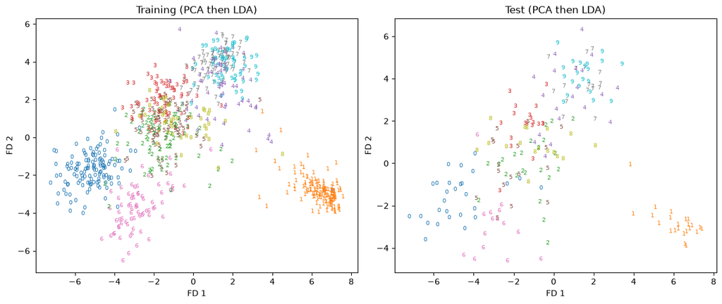

```python
newF      = new_digits_lda.transform(newX_train)
newF_test = new_digits_lda.transform(newX_test)

fig, axes = plt.subplots(1, 2, figsize=(12, 5), constrained_layout=True)
plot_ld_text(axes[0], newF,      Y_train, "Training (PCA then LDA)")
plot_ld_text(axes[1], newF_test, Y_test,  "Test (PCA then LDA)")
plt.show()
```

Training separation is less dramatic after the $256 \to 100$ compression, but the training and test pictures are more consistent — the usual signature that we have given up some overfit.

### Naive Bayes prediction

As a high-dimensional baseline we fit Gaussian naive Bayes to a two-class slice (digits 1 versus 7). Restricting to two classes makes the confusion matrix easy to read; `GaussianNB` will also run on all ten digits. This is the counterpart of `e1071::naiveBayes` used on numeric features.

```python
zip17_train = train_zip[train_zip.iloc[:, 0].isin([1, 7])].reset_index(drop=True)
zip17_test  = test_zip[test_zip.iloc[:, 0].isin([1, 7])].reset_index(drop=True)

Y_17      = zip17_train.iloc[:, 0].to_numpy(dtype=int)
X_17      = zip17_train.iloc[:, 1:].to_numpy(dtype=float)
Y_17_test = zip17_test.iloc[:, 0].to_numpy(dtype=int)
X_17_test = zip17_test.iloc[:, 1:].to_numpy(dtype=float)

NBfit = GaussianNB()
NBfit.fit(X_17, Y_17)

y_pred = NBfit.predict(X_17_test)
print(f"Naive Bayes test accuracy (1 vs 7): {accuracy_score(Y_17_test, y_pred):.3f}")
print(pd.crosstab(pd.Series(y_pred, name="Predicted"),
                  pd.Series(Y_17_test, name="Actual")))
```

```
Naive Bayes test accuracy (1 vs 7): 0.950
Actual      1   7
Predicted
1          22   1
7           1  16
```